# Rojalin jena-solved honeyproduction dataset

## PART-2

## Data Visualization on Honey Production dataset using seaborn and matplotlib libraries

##### In 2006, a global concern was raised over the rapid decline in the honeybee population, an integral component to American honey agriculture. Large numbers of hives were lost to “Colony-Collapse-Disorder”, a phenomenon of disappearing “worker-bees” causing the remaining “hive-colony” to collapse. Speculation around the cause of this disorder points to hive-diseases and pesticides harming the pollinators, though no overall consensus has been reached. Twelve years later, some industries are observing recovery but the American honey industry is still largely struggling. The U.S. used to locally produce over half the honey it consumes per year. Now, honey mostly comes from overseas, with 350 of the 400 million pounds of honeyconsumed every year originating from imports. This dataset provides insight into honey production supply anddemand in America by state from 1998 to 2012.

### Domain: Food and agriculture

##### Objective:

The Goal is to use Python visualization libraries such as seaborn and matplotlib to investigate the data and get some useful conclusions.

### Attribute Information:

Slno Attribute Description

1. numcol :Number of honey producing colonies.
2. yield :percol Honey yield per colony. (Unit is pounds)
3. total :prod Total production (numcol x yieldpercol). (Unit is pounds)
4. price per lb: Refers to average price per pound based on expanded sales. Unit is dollars.
5. prodvalue: Value of production (total prod x priceperlb). Unit is dollars.
6. Stocks: Refers to stocks held by producers. Unit is pounds
7. Year: Calendar year.
8. State :Different states' names.

## 1.Import required libraries and read the dataset?

```python
import pandas as pd
import numpy as np
import seaborn as sns
import matplotlib.pyplot as plt
%matplotlib inline
from warnings import filterwarnings
filterwarnings("ignore")
```

```python
hp=pd.read_csv(r"C:\Users\payal jena\Downloads\honeyproduction.csv")
```

```python
hp
```

|  | state | numcol | yieldpercol | totalprod | stocks | priceperlb | prodvalue | year |
| --- | --- | --- | --- | --- | --- | --- | --- | --- |
| 0 | AL | 16000.0 | 71 | 1136000.0 | 159000.0 | 0.72 | 818000.0 | 1998 |
| 1 | AZ | 55000.0 | 60 | 3300000.0 | 1485000.0 | 0.64 | 2112000.0 | 1998 |
| 2 | AR | 53000.0 | 65 | 3445000.0 | 1688000.0 | 0.59 | 2033000.0 | 1998 |
| 3 | CA | 450000.0 | 83 | 37350000.0 | 12326000.0 | 0.62 | 23157000.0 | 1998 |
| 4 | CO | 27000.0 | 72 | 1944000.0 | 1594000.0 | 0.70 | 1361000.0 | 1998 |
| ... | ... | ... | ... | ... | ... | ... | ... | ... |
| 621 | VA | 4000.0 | 41 | 164000.0 | 23000.0 | 3.77 | 618000.0 | 2012 |
| 622 | WA | 62000.0 | 41 | 2542000.0 | 1017000.0 | 2.38 | 6050000.0 | 2012 |
| 623 | WV | 6000.0 | 48 | 288000.0 | 95000.0 | 2.91 | 838000.0 | 2012 |
| 624 | WI | 60000.0 | 69 | 4140000.0 | 1863000.0 | 2.05 | 8487000.0 | 2012 |
| 625 | WY | 50000.0 | 51 | 2550000.0 | 459000.0 | 1.87 | 4769000.0 | 2012 |

626 rows × 8 columns

## 2.Check the first few samples, shape, info of the data and try to familiarize yourself with different?

```python
hp.head()
```

|  | state | numcol | yieldpercol | totalprod | stocks | priceperlb | prodvalue | year |
| --- | --- | --- | --- | --- | --- | --- | --- | --- |
| 0 | AL | 16000.0 | 71 | 1136000.0 | 159000.0 | 0.72 | 818000.0 | 1998 |
| 1 | AZ | 55000.0 | 60 | 3300000.0 | 1485000.0 | 0.64 | 2112000.0 | 1998 |
| 2 | AR | 53000.0 | 65 | 3445000.0 | 1688000.0 | 0.59 | 2033000.0 | 1998 |
| 3 | CA | 450000.0 | 83 | 37350000.0 | 12326000.0 | 0.62 | 23157000.0 | 1998 |
| 4 | CO | 27000.0 | 72 | 1944000.0 | 1594000.0 | 0.70 | 1361000.0 | 1998 |

```python
hp.shape
```

```
(626, 8)
```

```python
hp.info()
```

```
<class 'pandas.core.frame.DataFrame'>
RangeIndex: 626 entries, 0 to 625
Data columns (total 8 columns):
 #   Column       Non-Null Count  Dtype
---  ------       --------------  -----
 0   state        626 non-null    object
 1   numcol       626 non-null    float64
 2   yieldpercol  626 non-null    int64
 3   totalprod    626 non-null    float64
 4   stocks       626 non-null    float64
 5   priceperlb   626 non-null    float64
 6   prodvalue    626 non-null    float64
 7   year         626 non-null    int64
dtypes: float64(5), int64(2), object(1)
memory usage: 39.2+ KB
```

### 3.Display the percentage distribution of the data in each year using the pie chart?

```python
#group data by year
year_group = hp.groupby('year').sum()
```

```python
year_group
```

| year | numcol | yieldpercol | totalprod | stocks | priceperlb | prodvalue |
| --- | --- | --- | --- | --- | --- | --- |
| 1998 | 2621000.0 | 3008 | 219519000.0 | 80565000.0 | 35.80 | 146091000.0 |
| 1999 | 2637000.0 | 2815 | 202387000.0 | 78390000.0 | 34.58 | 123657000.0 |
| 2000 | 2604000.0 | 2906 | 219558000.0 | 84956000.0 | 34.03 | 131568000.0 |
| 2001 | 2542000.0 | 2840 | 185748000.0 | 64764000.0 | 40.12 | 132282000.0 |
| 2002 | 2565000.0 | 2939 | 171265000.0 | 39177000.0 | 60.34 | 227302000.0 |
| 2003 | 2591000.0 | 2752 | 181372000.0 | 40619000.0 | 65.77 | 252079000.0 |
| 2004 | 2539000.0 | 2657 | 182729000.0 | 60981000.0 | 52.67 | 197307000.0 |
| 2005 | 2394000.0 | 2635 | 173969000.0 | 62187000.0 | 49.00 | 160793000.0 |
| 2006 | 2378000.0 | 2536 | 154238000.0 | 60235000.0 | 53.45 | 157924000.0 |
| 2007 | 2428000.0 | 2426 | 147621000.0 | 52405000.0 | 58.97 | 161356000.0 |
| 2008 | 2326000.0 | 2501 | 162972000.0 | 50996000.0 | 66.65 | 229992000.0 |
| 2009 | 2472000.0 | 2154 | 145068000.0 | 37322000.0 | 72.48 | 213920000.0 |
| 2010 | 2666000.0 | 2251 | 175294000.0 | 44797000.0 | 77.16 | 278370000.0 |
| 2011 | 2466000.0 | 2191 | 147201000.0 | 36550000.0 | 86.69 | 258688000.0 |
| 2012 | 2509000.0 | 2207 | 140907000.0 | 31662000.0 | 94.68 | 280725000.0 |

```python
#calculate percentage of each year
year_percentage = year_group['totalprod']/year_group['totalprod'].sum()*100
year_percentage
```

```
year
1998    8.411180
1999    7.754743
2000    8.412674
2001    7.117196
2002    6.562260
2003    6.949523
2004    7.001519
2005    6.665867
2006    5.909846
2007    5.656306
2008    6.244502
2009    5.558485
2010    6.716636
2011    5.640214
2012    5.399050
Name: totalprod, dtype: float64
```

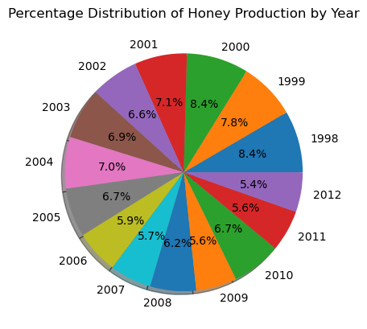

```python
#plot pie chart
plt.pie(year_percentage, labels=year_percentage.index, autopct='%1.1f%%', shadow=True)
plt.title('Percentage Distribution of Honey Production by Year')
plt.show()
```

### 4.Plot and Understand the distribution of the variable "price per lb" using displot, and write your findings?

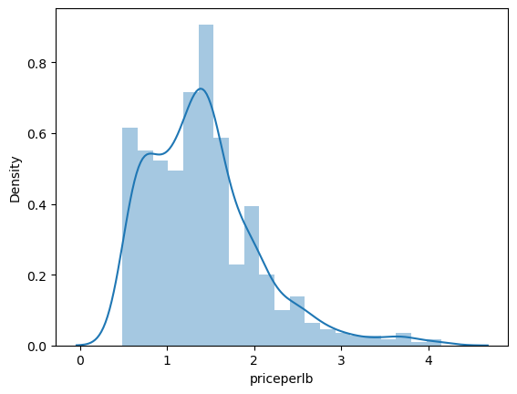

```python
#plotting the distribution of the variable "price per lb" using displot
sns.distplot(hp['priceperlb'])
plt.show()
```

### 5.Plot and understand the relationship between the variables 'numcol' and 'prodval' through scatterplot, and write your findings?

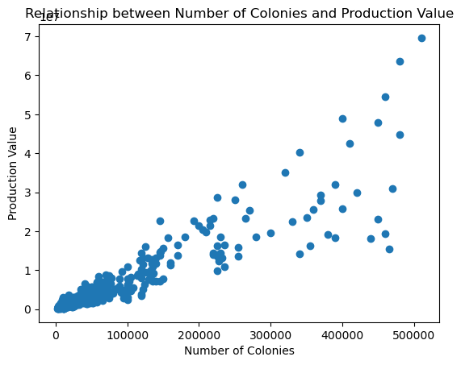

```python
#plotting the scatterplot
plt.scatter(hp['numcol'], hp['prodvalue'])
plt.xlabel('Number of Colonies')
plt.ylabel('Production Value')
plt.title('Relationship between Number of Colonies and Production Value')
plt.show()
```

It can observed that as the number of colonies increases the production value increases.

### 6.Plot and understand the relationship between categorical variable 'year' and a numerical variable 'prodvalue' through boxplot, and write your findings?

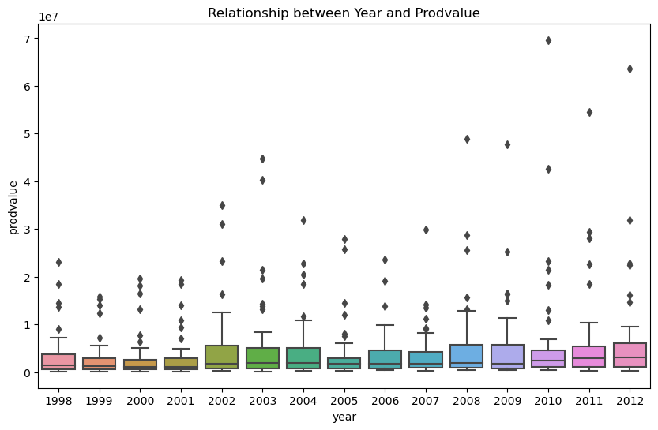

```python
 #plot boxplot
plt.figure(figsize=(10,6))
sns.boxplot(x='year', y='prodvalue', data=hp)
plt.title('Relationship between Year and Prodvalue')
plt.show()
```

Boxplot is used to summarize the data.The above boxplot summarises prodvalue per year . So as the year passes the sales also increases.

### 7.Visualize and understand the relationship between the multiple pairs of variables throughout different years using pairplot and add your inferences. (use columns 'numcol', 'yield percol', 'total prod', 'prodvalue','year')?

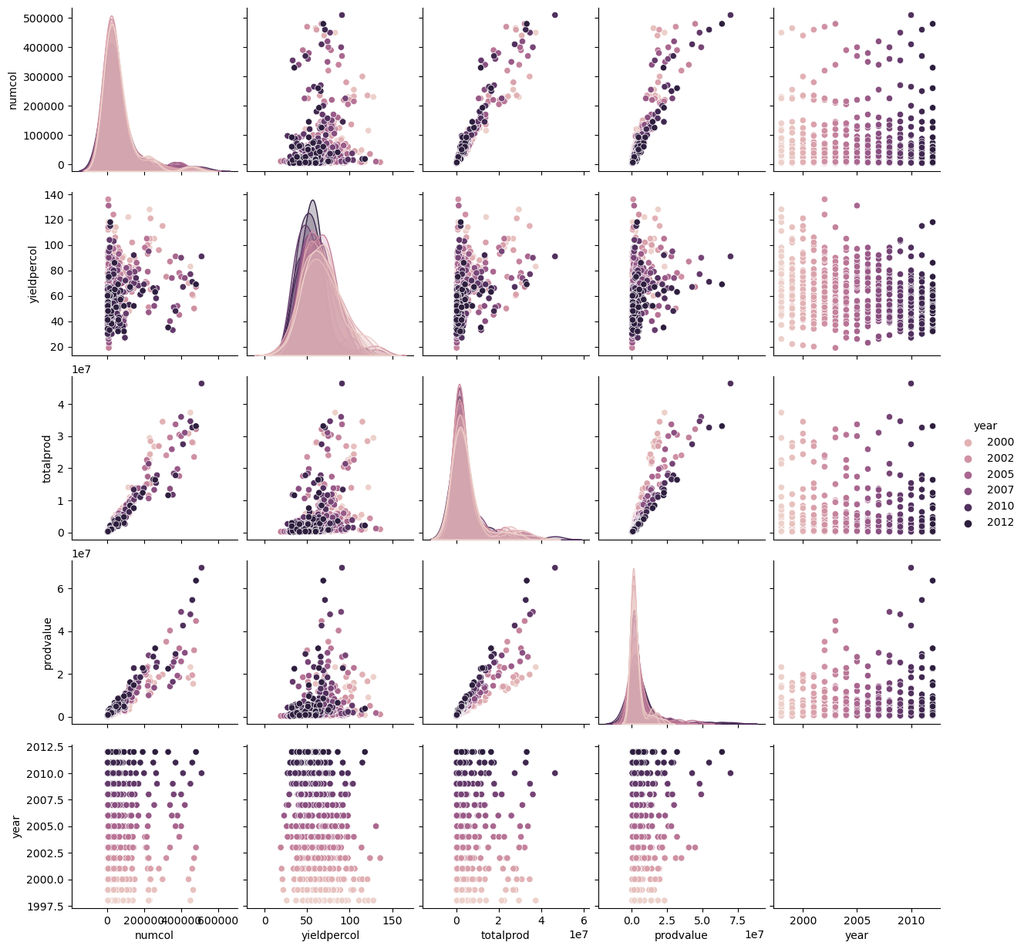

```python
# Create a pairplot of the dataframe
sns.pairplot(hp, vars=['numcol', 'yieldpercol', 'totalprod', 'prodvalue', 'year'], hue='year')

# Show the plot
plt.show()
```

### 8.Display the correlation values using a plot and add your inferences. (use columns 'numcol', 'yield percol', 'total prod', 'stocks', 'price per lb', 'prodvalue')?

```python
# select columns to plot
cols = ['numcol', 'yieldpercol', 'totalprod', 'stocks', 'priceperlb', 'prodvalue']
```

```python
cols
```

```
['numcol', 'yieldpercol', 'totalprod', 'stocks', 'priceperlb', 'prodvalue']
```

```python
# create correlation matrix
corr_matrix = hp[cols].corr()
```

```python
corr_matrix
```

|  | numcol | yieldpercol | totalprod | stocks | priceperlb | prodvalue |
| --- | --- | --- | --- | --- | --- | --- |
| numcol | 1.000000 | 0.243515 | 0.953594 | 0.825929 | -0.232701 | 0.912796 |
| yieldpercol | 0.243515 | 1.000000 | 0.396252 | 0.367812 | -0.358646 | 0.278977 |
| totalprod | 0.953594 | 0.396252 | 1.000000 | 0.878830 | -0.264499 | 0.907236 |
| stocks | 0.825929 | 0.367812 | 0.878830 | 1.000000 | -0.305867 | 0.728560 |
| priceperlb | -0.232701 | -0.358646 | -0.264499 | -0.305867 | 1.000000 | -0.089567 |
| prodvalue | 0.912796 | 0.278977 | 0.907236 | 0.728560 | -0.089567 | 1.000000 |

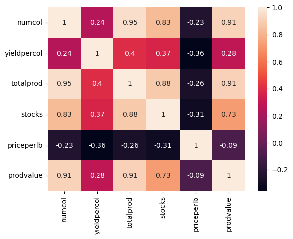

```python
# plot correlation matrix using seaborn heatmap
sns.heatmap(corr_matrix, annot=True)
plt.show()
```

Heat maps are used to present the correlation matrix.It can be observed that prodvalue and numcol & totalprod and numcol are highly positively correlated .Whereas yieldpercol and priceperlb & stocks and priceperlb are negatively correlated.